# Handwriting Analysis: Exploratory Data Analysis & Experimental Setup

Questions 1 and 4 Complete Report

## Section 1: Exploratory Data Analysis

### Global Dataset Profile overview

The handwriting dataset evaluated in this study constitutes a completely uniform, synthetically balanced array designed for writer identification and verification tasks. It contains a total population of 25,000 unique images mapped across a multi-dimensional recording matrix. The underlying data distribution is structured as follows:

- **Writers (20):** Represented by `person_id` ranging from 1 to 20.
- **Characters (5):** Represented by `digit` spanning 0 to 4.
- **Temporal Intervals (5):** Represented by `session` tracking blocks 1 to 5.
- **Replicate Volume (50):** Represented by `replicate` indicating repeated frames from 1 to 50 captured sequentially within a single sitting.

The data collection is entirely free from any structural class imbalances as it contains exactly 50 replicates for every single intersecting combination of person, digit, and session ($20 \times 5 \times 5 \times 50 = 25,000$). This perfect alignment avoids standard sampling biases,thus overall accuracy metrics will remain uninflated by majority-class dominance.

The raw data image is formatted as integer elements ranging from 0 (representing the blank background canvas) to 255 (representing the maximum ink density path). The image pixel values were scaled to [0,1] before fitting the models as it will cause numerical instability during early backpropagation rounds. (this paragraph could probably be moved to the end of q1)

Moreover, each person has a consistent handwriting style, but their writing style fluctuates between the 5 recording due to various factors - different writing materials or natural variation.

### Analysis of Visible Sources of Variation

#### Inter-Writer Style Variation

In order to examine the inter-writer style variation the single character class (digit 0) across the first 5 writers is analysed in the figure below. It is evident that there is a clear variation in the writing style of each writer. For instance, writer 1’s character leans towards the left with an asymmetrical top loop whereas writer 2 produces uniform stroke borders with flat horizontal loops. Furthermore, writer 3 produces a small, pinched dense circle unlike writers 4 and 5 with larger round circles where writer 4 is less symmetrical than writer 5. These differences act as key identity signals that convolutional filters can easily latch onto to identify writers.

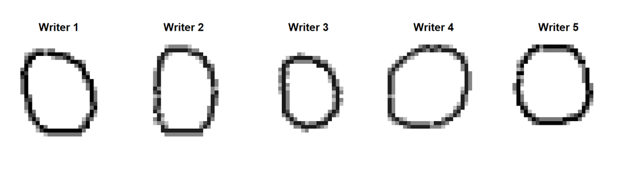

Figure 1: Digit 0 written by Writers 1 to 5 (inter-writer style variation)

#### Consistent Individual Handwriting Signatures

When tracking multiple characters produced by a single hand, a cohesive, cross-character fingerprint becomes apparent. For example, evaluating Writer 1 the writer maintains a perfectly upright, non-slanted angle across all stroke length. Conversely, when evaluating writer 10 in session 5 it is evident that the writer sustains a slanted angle to the right across all digits. This verifies that personal writing styles carry over into different character geometries.

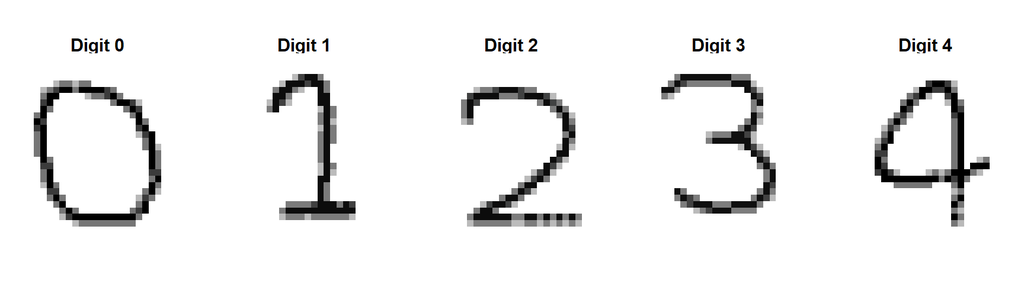

Figure 2: Digits 0 to 4 written by Writer 1 (consistent individual signature)

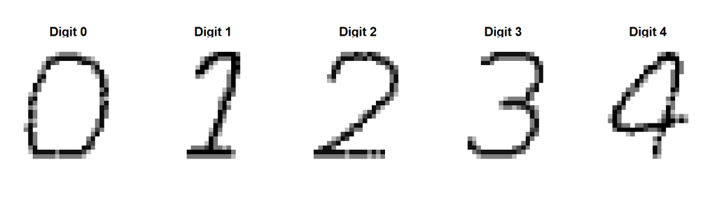

#### Temporal Session Drift

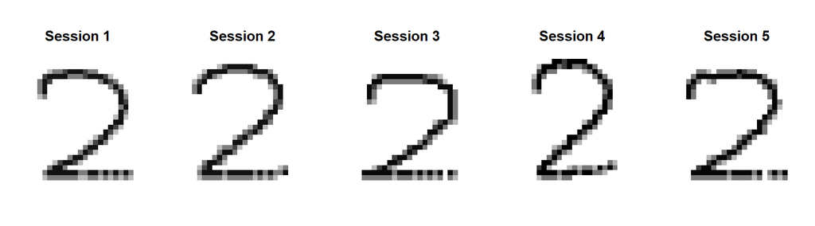

Figure 3: Digit 2 by Writer 1 across Sessions 1 to 5 (temporal drift)

### Limitations of the Simulated Data

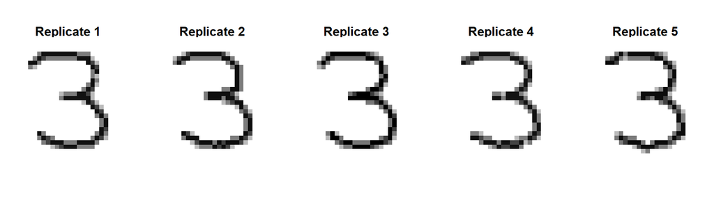

Figure 4: Digit 3 by Writer 1, Session 1, Replicates 1 to 5

## Section 3: Writer Verification using a Siamese Network

### Data Preparation

The handwriting images were loaded and scaled by dividing the pixel values by 255. This converted all pixel values to the range 0 to 1, which helps the neural network train more effectively. The data was split by session to avoid data leakage. Sessions 1 to 3 were used for training, session 4 for validation, and session 5 for testing.

### Construction of Training Examples

Training examples were created as pairs of images. For each pair, there was a 50% chance that both images came from the same writer and a 50% chance that they came from different writers.

A label of 1 was assigned if the two images were written by the same person, and a label of 0 was assigned if they were written by different people. This balanced set of positive and negative pairs allowed the model to learn writer similarity.

| Dataset | Number_of_Pairs | Positive_Pair_Proportion |
| --- | --- | --- |
| Training | 20000 | 0.4962 |
| Validation | 5000 | 0.4922 |
| Test | 5000 | 0.5042 |

### Shared Encoder Network

A convolutional neural network (CNN) was used as the shared encoder. The encoder consisted of three convolutional layers with ReLU activation functions and max-pooling layers for feature extraction.

The encoder transformed each handwriting image into a compact feature representation that captured important writer characteristics.

### Siamese Network Architecture

The Siamese network contained two identical branches that shared the same encoder weights. Each branch processed one image from a pair.

The feature vectors produced by the encoder were compared using Euclidean distance. Small distances indicated that the images were likely written by the same person, while larger distances suggested different writers.

### Contrastive Loss Function

The model was trained using contrastive loss with a margin of 1.

For pairs from the same writer, the loss function encouraged the distance between embeddings to become smaller. For pairs from different writers, the loss function encouraged the distance to be greater than the margin. This helped the network learn a feature space where handwriting from the same writer was grouped together and handwriting from different writers was separated.

### Model Training

Early stopping was applied using the validation loss from session 4. Training stopped automatically if the validation loss did not improve for three consecutive epochs, helping to reduce overfitting.

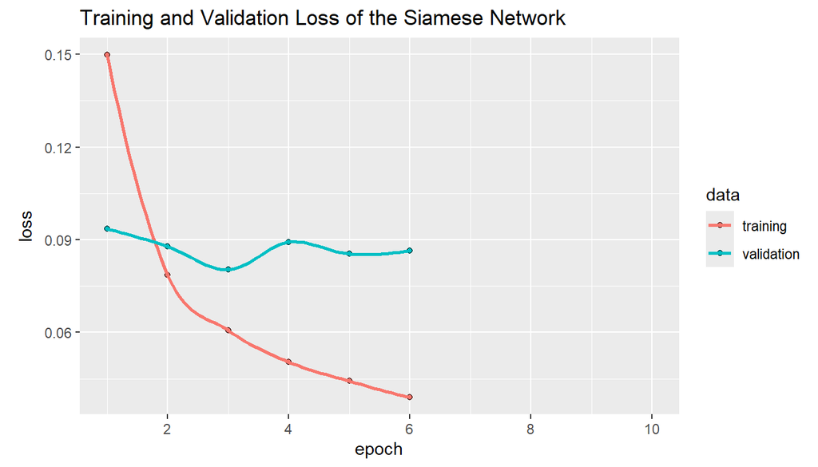

Figure 5: Training and validation loss of the Siamese network over training epochs.

The training loss decreased steadily from approximately 0.15 to 0.04, showing that the model learned the training data effectively. The validation loss decreased initially but then remained relatively constant, suggesting that the model generalised well with only slight signs of overfitting after the first few epochs.

### Threshold Selection

The Siamese network outputs a distance rather than a direct same-or-different prediction. A decision threshold was therefore selected using the validation set.

Distances below the threshold were classified as the same writer, while distances above the threshold were classified as different writers. The threshold that achieved the highest balanced accuracy on the validation set was chosen.

Threshold Selection Based on Validation Set Balanced Accuracy

| Threshold | Balanced_Accuracy | Selected |
| --- | --- | --- |
| 0.2339 | 0.7456 |  |
| 0.4788 | 0.9207 |  |
| 1.0425 | 0.7422 |  |
| 0.4814 | 0.9217 | ✓ Best |

### Evaluation of Matching Performance

The final model was evaluated on the independent test set from session 5. Matching performance was measured using:

- Accuracy: proportion of correctly classified pairs.
- True Positive Rate (Recall): proportion of same-writer pairs correctly identified.
- False Positive Rate: proportion of different-writer pairs incorrectly classified as the same writer.
- False Negative Rate: proportion of same-writer pairs incorrectly classified as different writers.
- F1 Score: harmonic mean of precision and recall.
- Area Under the ROC Curve (AUC): measures how well the model separates same-writer and different-writer pairs across all possible thresholds.

Table 2: Test Set Performance Metrics for the Siamese Network

| Metric | Value |
| --- | --- |
| Accuracy | 0.9170 |
| Recall (TPR / Sensitivity) | 0.9056 |
| Precision | 0.9280 |
| F1-Score | 0.9167 |
| False Positive Rate (FPR) | 0.0714 |
| False Negative Rate (FNR) | 0.0944 |
| AUC | 0.9746 |

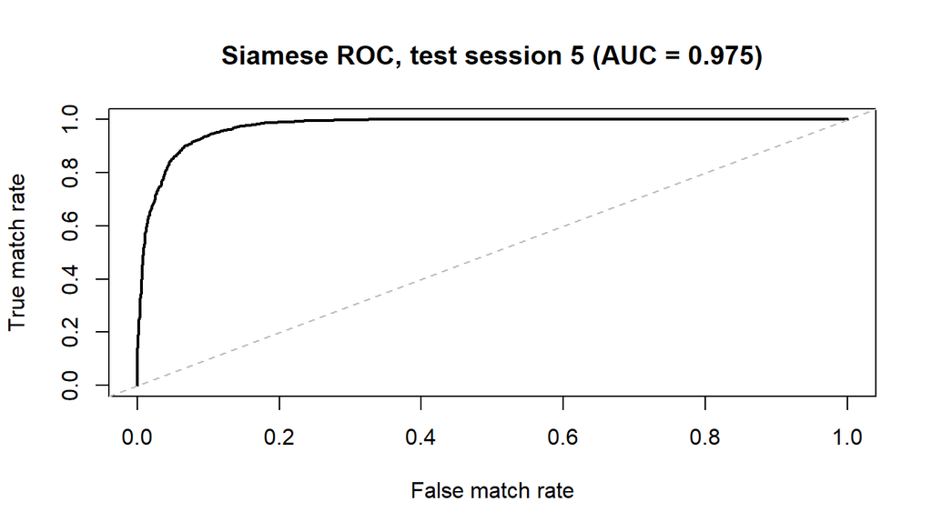

Figure 6: Siamese Network ROC

## Section 4: Data Partition Strategy

### Candidate Strategy Critique

The provided dataset is structured across multiple distinct dimensions (writers, digits, recording sessions, and replicates), which allows for several potential train, validation, and test partitioning strategies. These include a standard random split, a split by individual writer, a split by digit, and a split by session. For this assessment, the most optimal strategy is to partition the dataset strictly by session.

### 1. The Random 80/20 Partition

Utilising a random 80/20 split will result in a split that is not dependent on writer, digit or session. However each writer wrote the exact same digits, 0 - 4, 50 times in a single session thus some of these identical replicates will be in the training set and others in the test set leading to severe spatial-temporal data leakage. Moreover, the performance metrics become heavily over-optimistic as the model simply memorizes specific pixel configurations it has already seen, rather than learning generalizable human writing styles.

### 2. Split by Individual Writer

In contrast, splitting by individual eliminates leakage as certain writers will never appear in the training pool. For example writers 1- 16 in the training pool and writers 17 - 20 in the test pool. This split is optimal for the Siamese network as it gives a non-optimistic view of verification - to authenticate if two completely unknown hands belong to the same person. However this split breaks the CNN classifier as the model cannot predict or classify the output for writer 17 with only having the output nodes for 1-16.

### 3. Split by Digit

Similarly, splitting the data by digit will result in the CNN model breaking. While training the model will learn a specific combination of strokes tied to specific character shapes however when presented with a new digit in test it will fail as the geometric structure of the number is foreign. However the Siamese network successfully handles a digit split as it bypasses discrete classification entirely and will take on the general style from the digits in training and apply that information to the test data.

### 4. Justification for the Session-Based Split

Overall, splitting the train and test data by session is the optimal strategy. This approach provides an identical, perfectly balanced evaluation ground for both the Siamese network and CNN. he CNN retains access to all 20 output classes, while the Siamese network can fairly evaluate similarity metrics across all 5 available digits. Furthermore, there is no optimistic bias or data leakage as session 5 is kept separate from the training loop. Lastly this strategy is optimal as it will be able to handle natural style drift over time (e.g., hand fatigue, mood changes, or stylus wear between sessions) by being trained on historical data (sessions 1 -3), validated on session 4, and tested on future data (Session 5) . This evaluation strategy represents a measure of the Temporal Style Generalisation within a Closed-Universe System. Thus by splitting by session all writers and all digits are preserved across both models.

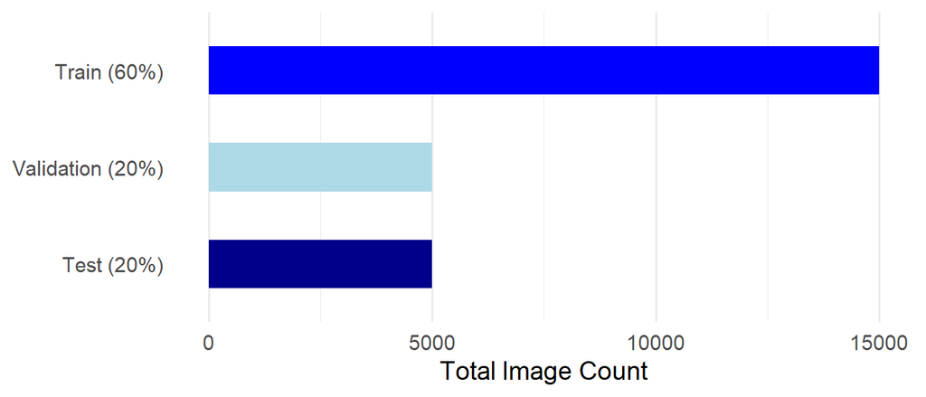

Figure 7: Chronological session partition blueprint